# League of Legends Diamond Ranked Games

Bocioroaga George

5/26/2020

# Introducere

“League of Legends” (prescurtat ca LOL) este un joc competitiv MOBA de eroi online dezvoltat de Riot Games.

În joc există sute de eroi personalizați, precum și un sistem de clasament, un sistem de rune și alte sisteme de dezvoltare caracteristice.

„League of Legends” se angajează, de asemenea, să promoveze dezvoltarea e-sporturilor globale. Pe lângă legarea diferitelor regiuni pentru a dezvolta ligi profesionale și a crea un sistem e-sport, va organiza, de asemenea, mid-season championship“,”global finals" si “All Star All-Star Game” în fiecare an. Cele trei evenimente de talie mondială au câștigat dragostea a sute de milioane de jucători și au format propria lor cultură e-sport unică.

Conținutul acestui raport va analiza în principal diferența dintre **grupul câștigător** și **grupul pierzător**.

# File descriptions

high_diamond_ranked_10min.csv - Primele zece minute ale meciului din clasamentul cu diamante League of Legends.

# Incarcarea pachetolor si a datelor

```r
library(tidyverse)
library(dplyr)
library(ggplot2)
library(caret)
library(randomForest)
library(corrplot)

data <- read.csv("C:/Users/George/Desktop/high_diamond_ranked_10min.csv")
```

# Curatarea datelor

```r
league_data <- read.csv("C:/Users/George/Desktop/high_diamond_ranked_10min.csv", stringsAsFactors = FALSE)
league_data_update <- league_data_update <- league_data[, -c(22:40)]
```

# Cum infuenteaza aurul rata de câștig

Una dintre cele mai importante caracteristici ale jocului este câștigul de aur. Pentru avantaje strategice, jucătorii concurează pentru câștigurile de aur, deoarece este o parte crucială a consolidării personajelor lor. Vom compara rata de câștig observată între echipa cu mai mult aur decât adversarii și invers.

Am creat o nouă variabilă “dif_true”, care clasifică un joc cu aur negativ câștigat ca 1 și pierdut ca 0. Luând media “BlueWins” separată de variabila “dif_true” ne arată procentul de joc câștigat cu diferențe de aur pozitive și diferențe de aur negative.

```r
num_function <- function(num){
  if(num > 0) {
return(0)
} else {
if(num == 0) {
return(0)
} else {
return(1)
}}}

league_data_update <- mutate(league_data_update,diff_true = sapply(league_data_update$blueGoldDiff, FUN = num_function, simplify = TRUE, USE.NAMES = TRUE))
league_data_update %>%
    group_by(diff_true) %>%
    summarise(win_rate = mean(blueWins, na.rm = TRUE))
```

| diff_true | win_rate |
| --- | --- |
| 0 | 0.7208787 |
| 1 | 0.2751678 |

Rezultatul arată că aproximativ 72% din jocurile cu câștig de aur pozitiv au fost câștigate, în timp ce doar 27% din jocuri au fost câștigate cu venituri negative din aur. Aceasta nu ar trebui să fie o surpriză, deoarece veniturile din aur sunt direct legate, prin faptul că putem cumpara mai multe obiecte(items) și pentru a deveni un personaj mai puternic decât adversarii.

# Venituri de aur pentru a câștiga rata: după cât de mult?

Acum că am stabilit modul în care diferențele de obținere a aurului sunt cruciale pentru a câștiga, dorim să analizăm mai îndeaproape cât de mult diferența de aur poate avea impact asupra câștigului. Pentru aceasta, am creat o variabilă suplimentară pentru a separa „blueGoldDiff” într-o gamă diferită. Această nouă variabilă clasifică 0 pentru câștiguri de aur egale sau mai mari, 1,2,3,4 pentru fiecare diferență de aur de 1 k.

```r
num_function_2 <- function(num){
if (num >= 0 ) {
return(0)
} else if ( num >= - 1000 ) {
return(1)
} else if ( num >= - 2000) {
return(2)
} else if (num >= - 3000) {
  return(3)}
  else{
return(4)
}}

league_data_update <- mutate(league_data_update,diff_true_2 = sapply(league_data_update$blueGoldDiff, FUN = num_function_2, simplify = TRUE, USE.NAMES = TRUE))

league_data_update %>%
    group_by(diff_true_2) %>%
    summarise(win_rate = mean(blueWins, na.rm = TRUE))
```

| diff_true_2 | win_rate |
| --- | --- |
| 0 | 0.72087868 |
| 1 | 0.42778119 |
| 2 | 0.29213483 |
| 3 | 0.19213974 |
| 4 | 0.08758422 |

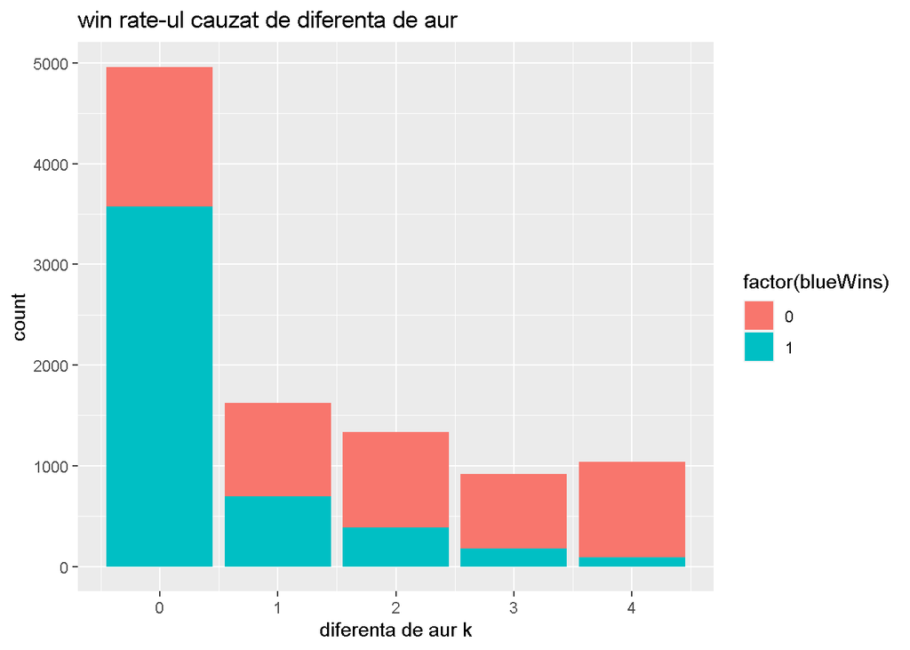

```r
ggplot(league_data_update, aes(diff_true_2,,fill=factor(blueWins))) +
  geom_bar() + ggtitle('win rate-ul cauzat de diferenta de aur') + xlab('diferenta de aur k')
```

Din graficul cu bare, observăm o tendință descendentă între rata câștigului și câștigul de aur. Pe măsură ce diferența negativă a câștigurilor din aur crește, procentul jocurilor pierdute crește. Aceasta susține constatările anterioare ale modului în care sunt corelate rata câștigului și diferențele de aur.

# Numarul de minioni omorati si venitul de aur

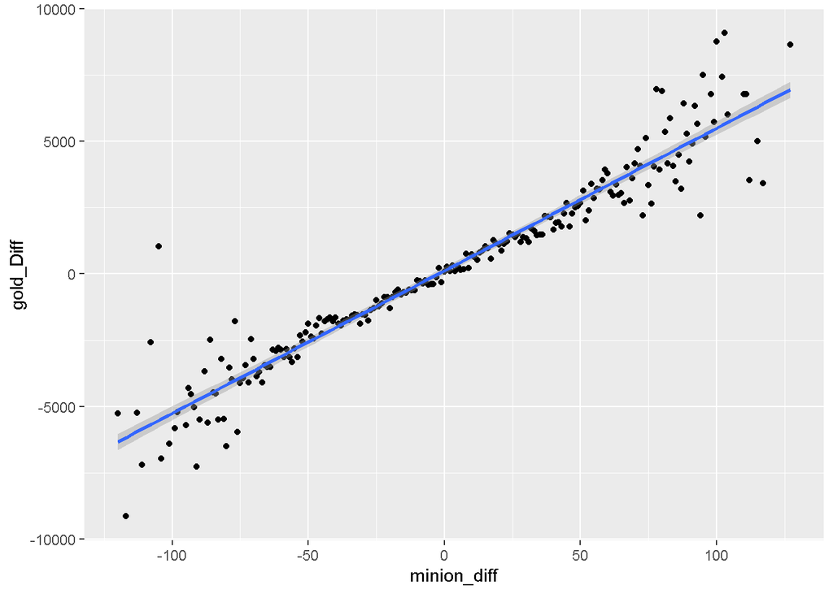

```r
league_data_update <- mutate(league_data,minion_diff = blueTotalMinionsKilled - redTotalMinionsKilled)


minion <-league_data_update %>%
    group_by(minion_diff) %>%
    summarise(gold_Diff = mean(blueGoldDiff, na.rm = TRUE))


ggplot(minion, aes(minion_diff,gold_Diff)) + geom_point() + geom_smooth(method=lm)
```

```r
print(minion)
```

```
## # A tibble: 213 x 2
##    minion_diff gold_Diff
##          <int>     <dbl>
##  1        -120    -5264
##  2        -117    -9152
##  3        -113    -5253
##  4        -111    -7206
##  5        -108    -2579
##  6        -105     1031
##  7        -104    -6973
##  8        -101    -6404.
##  9         -99    -5826.
## 10         -98    -5219
## # ... with 203 more rows
```

# Matrice de corelatie

[figure not shown]

```r
CorrMatrix<-cor(league_data_update%>%select(-1))
corrplot(CorrMatrix,method = "color",type = "full",
         order = "hclust",addCoef.col = "black",
         tl.srt = 40,tl.cex = 0.7,number.cex = 0.55)
```

O matrice de corelație este un tabel care prezintă coeficienții de corelație între variabile. Fiecare celulă din tabel arată corelația dintre două variabile. O matrice de corelație este utilizată pentru a rezuma datele, ca o intrare într-o analiză mai avansată și ca un diagnostic pentru analize avansate.

De obicei, o matrice de corelație este „pătrată” (ca in cazul de fata), cu aceleași variabile prezentate în rânduri și coloane. Aceasta arată corelații între importanța declarată a diferitelor lucruri pentru League of Legends. Linia de 1 care merge de la stânga sus la dreapta jos este diagonală principală , ceea ce arată că fiecare variabilă se corelează întotdeauna perfect cu ea însăși. Această matrice este simetrică, cu aceeași corelație, este prezentată deasupra diagonalei principale fiind o imagine în oglindă a celor de sub diagonala principală.

# Ward plasat/distrus pentru win rate

Ward-urile sunt obiecte care, odată instalate, oferă viziune către o locație nemarcată. Ward-urile sunt utilizate pentru a localiza mișcările inamice și pentru a oferi un avantaj tactic asupra unei anumite regiuni într-un joc. Vom compara media de plasari și distrugeri de ward-urile într-un joc cu rezultatul jocului (câștigați ca 1, pierdeți ca 0).

```r
league_data_update %>%
    group_by(blueWins) %>%
    summarise(avg_ward_placed = mean(blueWardsPlaced, na.rm = TRUE))
```

| blueWins | avg_ward_placed |
| --- | --- |
| 0 | 22.28672 |
| 1 | 22.28986 |

```r
league_data_update %>%
    group_by(blueWins) %>%
    summarise(avg_ward_destroyed = mean(blueWardsDestroyed, na.rm = TRUE))
```

| blueWins | avg_ward_destroyed |
| --- | --- |
| 0 | 2.728834 |
| 1 | 2.921298 |

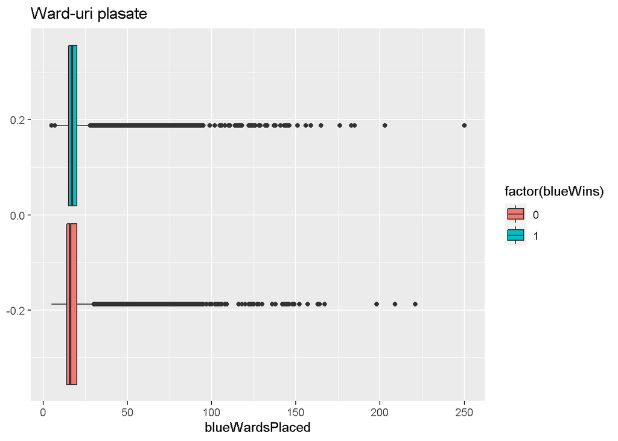

```r
ggplot(league_data_update, aes(blueWardsPlaced,fill=factor(blueWins))) +
  geom_boxplot() + ggtitle("Ward-uri plasate")
```

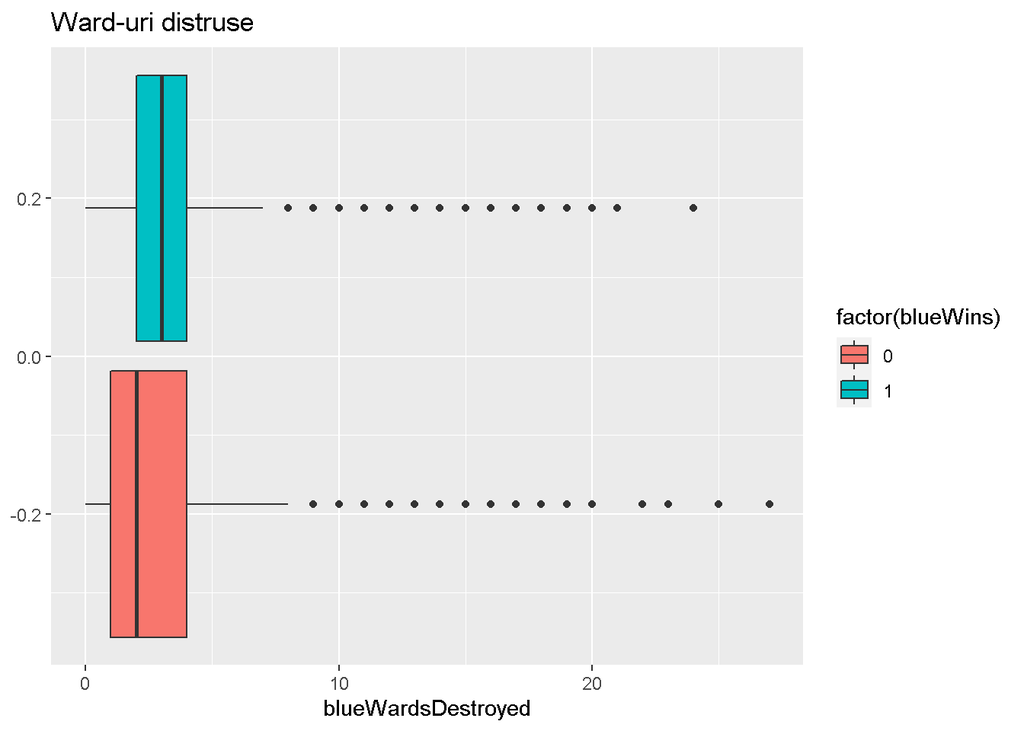

```r
ggplot(league_data_update, aes(blueWardsDestroyed,fill=factor(blueWins))) +
  geom_boxplot() + ggtitle("Ward-uri distruse")
```

Atât rezumatul statistic, cât și casetele arată o diferență mică sau nicio diferență între ward-urile plasate/distruse între jocurile câștigate și cele pierdute. Ward-ul mediu plasat atât pentru jocurile câștigate, cât și pentru cele pierdute este de aproximativ 22,28, iar ward-ul distrus in medie este de aproximativ 2,72 si 2,92.

# Diferenta kill-uri pentru win rate

Ultima caracteristică a jocului de analizat este numărul kill-uri legate de win rate. În cazul în care un inamic este ucis, inamicului îi este interzis să joace jocul pentru o perioadă de timp, iar asasinul castiga aur pentru kill-ul respectiv. În acest sens, numărul kill-urilor ar trebui să urmeze intuitiv aceeași tendință în raport cu win rate ca și câștigul aurului.

Pentru aceasta, am creat o nouă variabilă pentru diferența dintre kill-uri din partea echipei inamice. Pentru fiecare diferență de kill-uri, am calculat win rate pentru fiecare și am trasat o linie de regresie simplă.

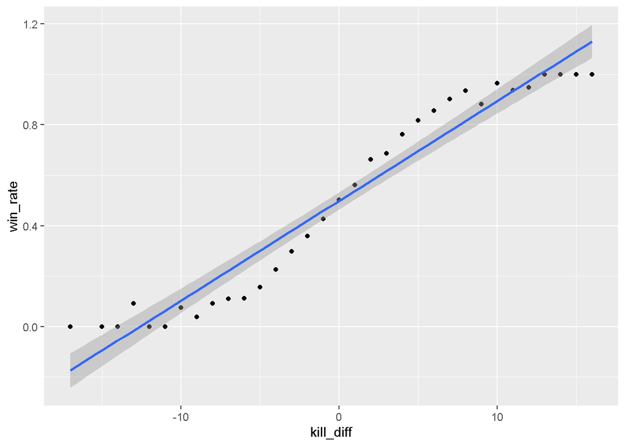

```r
league_data_update <- mutate(league_data,kill_diff = blueKills - redKills)


kill <-league_data_update %>%
    group_by(kill_diff) %>%
    summarise(win_rate = mean(blueWins, na.rm = TRUE))


ggplot(kill, aes(kill_diff,win_rate)) + geom_point() + geom_smooth(method=lm)
```

```r
regkill <- lm(win_rate ~ kill_diff,data = kill)
summary(regkill)
```

```
##
## Call:
## lm(formula = win_rate ~ kill_diff, data = kill)
##
## Residuals:
##      Min       1Q   Median       3Q      Max
## -0.14967 -0.08241 -0.01227  0.08514  0.17429
##
## Coefficients:
##             Estimate Std. Error t value Pr(>|t|)
## (Intercept)  0.49810    0.01647   30.24   <2e-16 ***
## kill_diff    0.03955    0.00172   22.99   <2e-16 ***
## ---
## Signif. codes:  0 '***' 0.001 '**' 0.01 '*' 0.05 '.' 0.1 ' ' 1
##
## Residual standard error: 0.09462 on 31 degrees of freedom
## Multiple R-squared:  0.9446, Adjusted R-squared:  0.9428
## F-statistic: 528.5 on 1 and 31 DF,  p-value: < 2.2e-16
```

# Random forest

```r
league_data_update$blueWins <- as.character(league_data_update$blueWins)
league_data_update$blueWins<- as.factor(league_data_update$blueWins)

n <- nrow(league_data_update)
#Preluam doar 80% dataset
n_train <- round(0.80 * n)

set.seed(123)
train_indices <- sample(1:n, n_train)

league_train <- league_data_update[train_indices, ]

league_test <- league_data_update[-train_indices, ]

paste("train sample size: ", dim(league_train)[1])
```

```
## [1] "train sample size:  7903"
```

```r
paste("test sample size: ", dim(league_test)[1])
```

```
## [1] "test sample size:  1976"
```

```r
league_rf <- randomForest(blueWins~ ., data=league_train, importance=TRUE,
proximity=TRUE)
print(league_rf )
```

```
##
## Call:
##  randomForest(formula = blueWins ~ ., data = league_train, importance = TRUE,      proximity = TRUE)
##                Type of random forest: classification
##                      Number of trees: 500
## No. of variables tried at each split: 6
##
##         OOB estimate of  error rate: 27.99%
## Confusion matrix:
##      0    1 class.error
## 0 2863 1097   0.2770202
## 1 1115 2828   0.2827796
```

```r
#league_train_target <- league_train$blueWins
league_test_target <- league_test$blueWins


league_test <- league_test [, !(colnames(league_test ) %in% c("blueWins"))]
pred_rf <- predict(league_rf, league_test)
CMrf<-confusionMatrix(data=pred_rf, league_test_target)

print(CMrf)
```

```
## Confusion Matrix and Statistics
##
##           Reference
## Prediction   0   1
##          0 716 252
##          1 273 735
##
##                Accuracy : 0.7343
##                  95% CI : (0.7142, 0.7537)
##     No Information Rate : 0.5005
##     P-Value [Acc > NIR] : <2e-16
##
##                   Kappa : 0.4686
##
##  Mcnemar's Test P-Value : 0.3827
##
##             Sensitivity : 0.7240
##             Specificity : 0.7447
##          Pos Pred Value : 0.7397
##          Neg Pred Value : 0.7292
##              Prevalence : 0.5005
##          Detection Rate : 0.3623
##    Detection Prevalence : 0.4899
##       Balanced Accuracy : 0.7343
##
##        'Positive' Class : 0
##
```

Pentru a înțelege algoritmul “random forest” trebuie mai întâi să introducem în discuție “decision trees” sau arborii de decizie. Ei sunt destul de intuitivi, întrucât nu reprezintă nimic mai mult decât un șir de decizii care pot fi luate într-o anumită situație.

“Random Forest” conține astfel mai mulți arbori de decizie ce funcționează ca un întreg. Fiecare arbore realizează o predicție iar mai apoi, ele sunt aduse împreună și este realizată o predicție cu acuratețe mai mare. Cu cât mai mulți arbori decizionali, cu atât mai mare precizia. e cumva general, dar am încercat să o pun cât de clar să înțelegem ceva